# Preliminary Analysis of the OPTN/UNOS Data

Fan Wu

April 25, 2016

# Contents

- Dates in the UNOS Datasets
- Brief Summary of the Data
- Diabetes Types as a Risk Factor
- Interaction between Time on Dialysis and Diabetes

## Dates in the UNOS Datasets

There are several dates related to the transplant candidate/recipients defined in the waiting list dataset and the post-transplant follow-up dataset (the ones used to defind the event of interest are in **bold**).

- `DIALYSIS_DATE`: WL date of initiation of regularly administered dialysis for ESRD (WL);
- `ACTIVATE_DATE`: date when qualifying criteria were first entered (WL);
- `INIT_DATE`: date placed on the waiting list (WL);
- `ADMISSION_DATE`: recipient date of admission to the TX ctr (TRR);
- `TX_DATE`: **transplant date** (TRR);
- `DEATH_DATE`: date died for patients removed from the WL for reason of death (WL);
- `COMPOSITE_DEATH_DATE`: **composite patient death date** from OPTN/external sources (TRR/TRF-Calc);
- `END_DATE`: earliest date of removal from the WL (TX, D, or EOS) (WL);
- `FAIL_DATE_KI`: **graft fail date** - kidney (TRR/TRF-Calc);
- `GRF_FAIL_DATE`: date of graft failure (KIF);
- `PX_STAT_DATE`: recipient status date at time of FU (KIF).

TOC

## Brief Summary of the Data

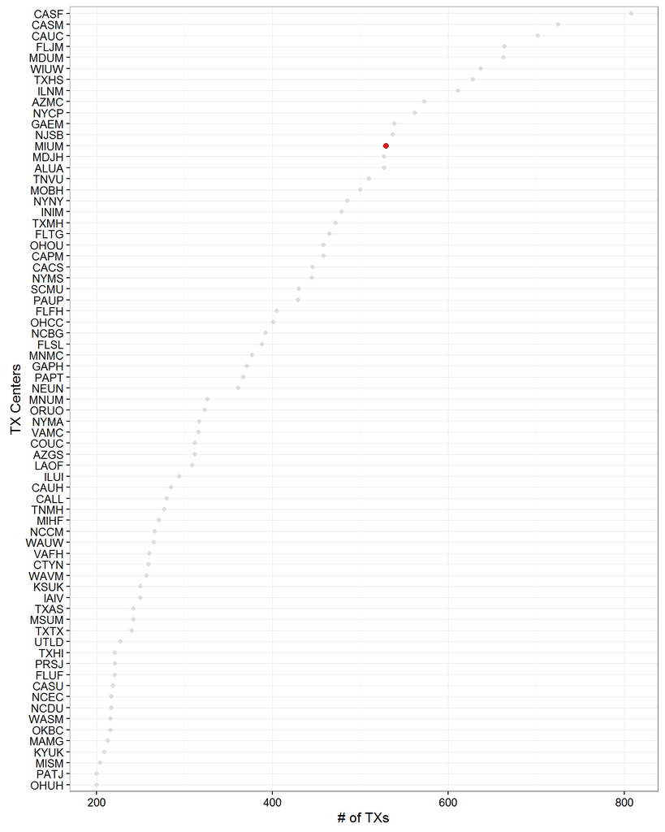

TOC

## Diabetes Types as a Risk Factor

The `DIAB` in the data are coded as follows:

- 1: No diabetes;
- 2: Type I diabetes;
- 3: Type II diabetes;
- 4: Unknown, Missing, Not Reported.

Within those centers with size $\geqslant$ 200, we also plot the % of diabetic patients (`DIAB = 2, 3, 4`) at TX.

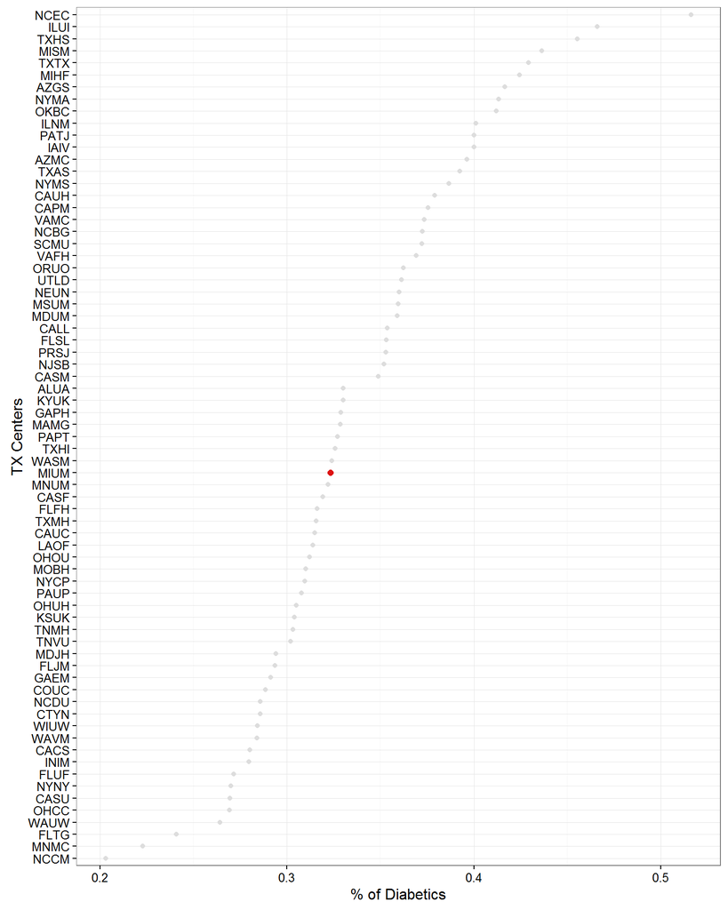

We first check cross table for diabetes types with one-year graft failure, one-year mortality, mean recipient age and % of PVD.

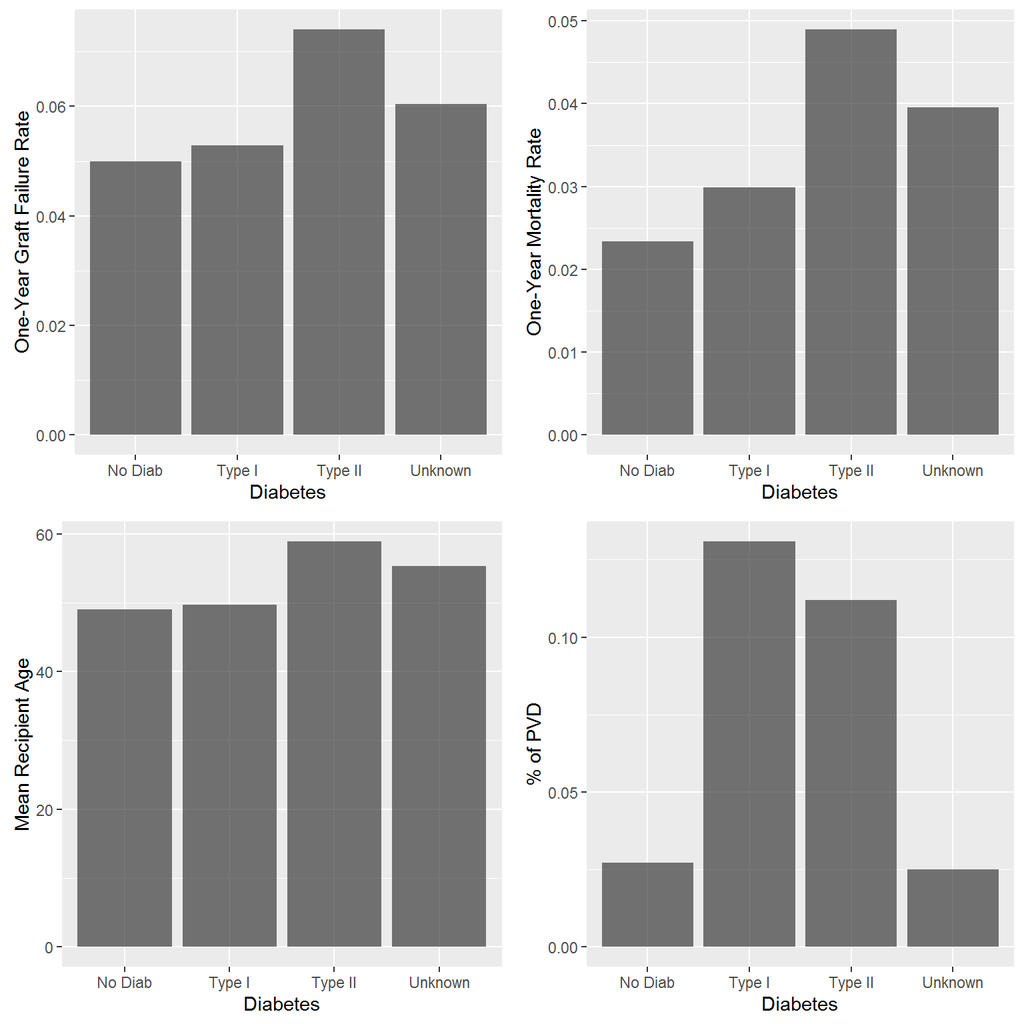

To check the effect of diabetes types on the graft failure rate and mortality rate by the time period after TX (3 mo, 3-6 mo, 6-12 mo).

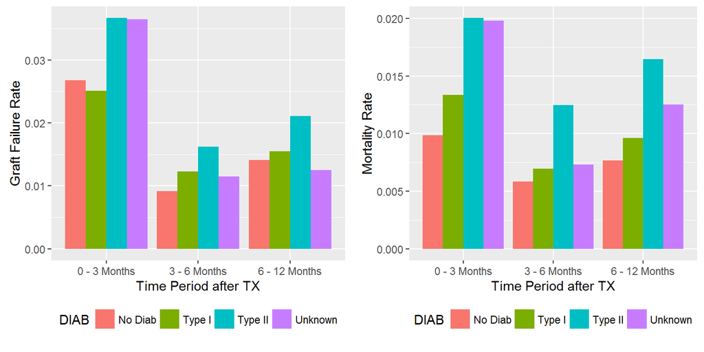

We then fit a stratified Cox model including all the risk factor listed as in our [plan](https://www-personal.umich.edu/~fannwu/SRTR/AnalysisPlan.docx) and using TX centers as the strata factor:

- Recipient: Age, race, sex, BMI, sensitization status (using cPRA), diabetes, peripheral vascular disease,
- Donor: Age, race, sex, BMI
- Transplantation: cold ischemia time, HLA mismatch ( 0-2,3-4, 5-6), type of organ (living versus deceased)

Separate models are fitted for graft (`T.GRF`) and patient (`T.PT`).

```
## Call:
## coxph(formula = Surv(T.GRF, D.GRF) ~ AGE + GENDER + ETHCAT +
##     DIAB + PERIP_VASC + BMI + AGE_DON + GENDER_DON + ETHCAT_DON +
##     BMI_DON + DON_TY + END_CPRA + COLD_ISCH_KI + HLAMISM + strata(TX_CTR),
##     data = unos)
##
##   n= 36634, number of events= 4343
##    (3349 observations deleted due to missingness)
##
##                              coef  exp(coef)   se(coef)       z Pr(>|z|)
## AGE                     0.0062382  1.0062577  0.0013738   4.541 5.60e-06 ***
## GENDERM                 0.0746324  1.0774880  0.0332446   2.245 0.024772 *
## ETHCATBlack             0.0211438  1.0213689  0.0398437   0.531 0.595650
## ETHCATHispanic         -0.3022428  0.7391586  0.0571694  -5.287 1.24e-07 ***
## ETHCATAsian            -0.3345916  0.7156303  0.0786878  -4.252 2.12e-05 ***
## ETHCATOther             0.0557900  1.0573756  0.1229331   0.454 0.649955
## DIABType I              0.1640312  1.1782511  0.0742605   2.209 0.027184 *
## DIABType II             0.2242827  1.2514247  0.0368049   6.094 1.10e-09 ***
## DIABUnknown             0.1426558  1.1533328  0.0985127   1.448 0.147590
## PERIP_VASCYes           0.3649078  1.4403811  0.0605351   6.028 1.66e-09 ***
## PERIP_VASCUnknown/Miss  0.0475398  1.0486879  0.1317479   0.361 0.718220
## BMINormal              -0.1742320  0.8401020  0.1177517  -1.480 0.138965
## BMIOverweight          -0.2432522  0.7840738  0.1177551  -2.066 0.038852 *
## BMIObese               -0.2342400  0.7911719  0.1177134  -1.990 0.046600 *
## AGE_DON                 0.0121400  1.0122140  0.0011499  10.558  < 2e-16 ***
## GENDER_DONM            -0.0619296  0.9399491  0.0317526  -1.950 0.051131 .
## ETHCAT_DONBlack         0.1701368  1.1854670  0.0447224   3.804 0.000142 ***
## ETHCAT_DONHispanic      0.0261916  1.0265376  0.0517273   0.506 0.612619
## ETHCAT_DONAsian         0.0635079  1.0655679  0.1022612   0.621 0.534576
## ETHCAT_DONOther        -0.0052553  0.9947585  0.1437142  -0.037 0.970830
## BMI_DONNormal          -0.2972396  0.7428660  0.0811934  -3.661 0.000251 ***
## BMI_DONOverweight      -0.3006745  0.7403187  0.0825231  -3.644 0.000269 ***
## BMI_DONObese           -0.2660022  0.7664374  0.0827692  -3.214 0.001310 **
## DON_TYL                -0.6498189  0.5221403  0.0556349 -11.680  < 2e-16 ***
## END_CPRA                0.0015286  1.0015298  0.0005112   2.990 0.002790 **
## COLD_ISCH_KI            0.0097600  1.0098078  0.0021182   4.608 4.07e-06 ***
## HLAMISM3-4              0.1067360  1.1126405  0.0501287   2.129 0.033234 *
## HLAMISM5-6              0.1915953  1.2111802  0.0505933   3.787 0.000152 ***
## ---
## Signif. codes:  0 '***' 0.001 '**' 0.01 '*' 0.05 '.' 0.1 ' ' 1
```

[output cut: 21 more lines]

```
## ETHCAT_DONOther           0.9948     1.0053    0.7506    1.3184
## BMI_DONNormal             0.7429     1.3461    0.6336    0.8710
## BMI_DONOverweight         0.7403     1.3508    0.6298    0.8703
## BMI_DONObese              0.7664     1.3047    0.6517    0.9014
## DON_TYL                   0.5221     1.9152    0.4682    0.5823
## END_CPRA                  1.0015     0.9985    1.0005    1.0025
## COLD_ISCH_KI              1.0098     0.9903    1.0056    1.0140
## HLAMISM3-4                1.1126     0.8988    1.0085    1.2275
## HLAMISM5-6                1.2112     0.8256    1.0968    1.3374
##
## Concordance= 0.639  (se = 0.049 )
## Rsquare= 0.024   (max possible= 0.692 )
## Likelihood ratio test= 883.5  on 28 df,   p=0
## Wald test            = 824.7  on 28 df,   p=0
## Score (logrank) test = 854  on 28 df,   p=0
```

```
## Call:
## coxph(formula = Surv(T.PT, D.PT) ~ AGE + GENDER + ETHCAT + DIAB +
##     PERIP_VASC + BMI + AGE_DON + GENDER_DON + ETHCAT_DON + BMI_DON +
##     DON_TY + END_CPRA + COLD_ISCH_KI + HLAMISM + strata(TX_CTR),
##     data = unos)
##
##   n= 36634, number of events= 2593
##    (3349 observations deleted due to missingness)
##
##                             coef exp(coef)  se(coef)      z Pr(>|z|)
## AGE                     0.040304  1.041127  0.002005 20.104  < 2e-16 ***
## GENDERM                 0.166881  1.181614  0.044236  3.773 0.000162 ***
## ETHCATBlack            -0.255366  0.774633  0.053905 -4.737 2.17e-06 ***
## ETHCATHispanic         -0.455389  0.634201  0.075117 -6.062 1.34e-09 ***
## ETHCATAsian            -0.517696  0.595892  0.103405 -5.007 5.54e-07 ***
## ETHCATOther            -0.059137  0.942578  0.156796 -0.377 0.706057
## DIABType I              0.455148  1.576407  0.092812  4.904 9.39e-07 ***
## DIABType II             0.465106  1.592183  0.046219 10.063  < 2e-16 ***
## DIABUnknown             0.424602  1.528982  0.119074  3.566 0.000363 ***
## PERIP_VASCYes           0.433830  1.543157  0.072063  6.020 1.74e-09 ***
## PERIP_VASCUnknown/Miss -0.271221  0.762448  0.183471 -1.478 0.139332
## BMINormal              -0.444410  0.641203  0.146643 -3.031 0.002441 **
## BMIOverweight          -0.651986  0.521010  0.146562 -4.449 8.65e-06 ***
## BMIObese               -0.687028  0.503069  0.146728 -4.682 2.84e-06 ***
## AGE_DON                 0.009652  1.009699  0.001480  6.522 6.96e-11 ***
## GENDER_DONM             0.043600  1.044564  0.041566  1.049 0.294210
## ETHCAT_DONBlack         0.085627  1.089400  0.061297  1.397 0.162434
## ETHCAT_DONHispanic      0.032946  1.033495  0.067295  0.490 0.624434
## ETHCAT_DONAsian         0.096407  1.101207  0.132411  0.728 0.466558
## ETHCAT_DONOther         0.159721  1.173184  0.178840  0.893 0.371806
## BMI_DONNormal          -0.178912  0.836180  0.114132 -1.568 0.116976
## BMI_DONOverweight      -0.125573  0.881992  0.115362 -1.089 0.276369
## BMI_DONObese           -0.138681  0.870505  0.115991 -1.196 0.231846
## DON_TYL                -0.708448  0.492408  0.073765 -9.604  < 2e-16 ***
## END_CPRA                0.002486  1.002489  0.000686  3.624 0.000291 ***
## COLD_ISCH_KI            0.006464  1.006485  0.002822  2.291 0.021979 *
## HLAMISM3-4              0.027918  1.028312  0.063506  0.440 0.660214
## HLAMISM5-6              0.089076  1.093164  0.064307  1.385 0.166003
## ---
## Signif. codes:  0 '***' 0.001 '**' 0.01 '*' 0.05 '.' 0.1 ' ' 1
```

[output cut: 21 more lines]

```
## ETHCAT_DONOther           1.1732     0.8524    0.8263    1.6657
## BMI_DONNormal             0.8362     1.1959    0.6686    1.0458
## BMI_DONOverweight         0.8820     1.1338    0.7035    1.1058
## BMI_DONObese              0.8705     1.1488    0.6935    1.0927
## DON_TYL                   0.4924     2.0308    0.4261    0.5690
## END_CPRA                  1.0025     0.9975    1.0011    1.0038
## COLD_ISCH_KI              1.0065     0.9936    1.0009    1.0121
## HLAMISM3-4                1.0283     0.9725    0.9080    1.1646
## HLAMISM5-6                1.0932     0.9148    0.9637    1.2400
##
## Concordance= 0.715  (se = 0.065 )
## Rsquare= 0.038   (max possible= 0.496 )
## Likelihood ratio test= 1416  on 28 df,   p=0
## Wald test            = 1235  on 28 df,   p=0
## Score (logrank) test = 1323  on 28 df,   p=0
```

## Interaction between Time on Dialysis and Diabetes

We first check the cross table between diabetes types and the dialysis time (pre-emptive: no dialysis recorded; 0-2 years, 2-4 years and 4 years+). The density plot of the exact time on dialysis is also plotted.

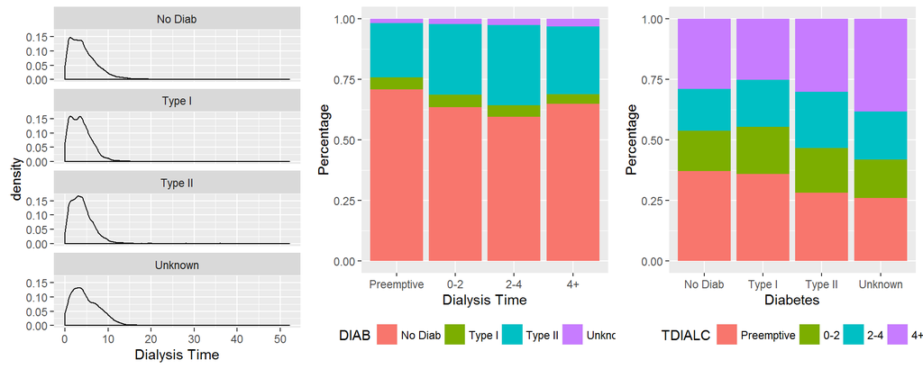

Then we inspect the one-year graft failure rate and the mortality rate for different combination of dialysis time and diabetes types.

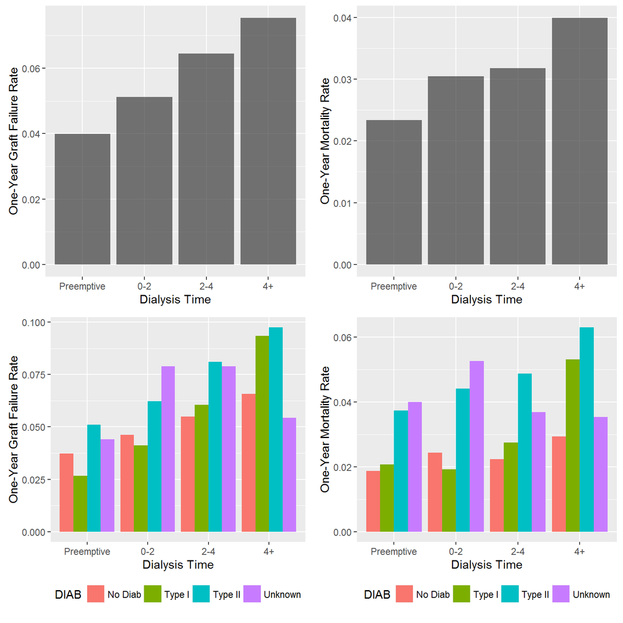

```
## Call:
## coxph(formula = Surv(T.GRF, D.GRF) ~ AGE + GENDER + ETHCAT +
##     DIAB * TDIALC + PERIP_VASC + BMI + AGE_DON + GENDER_DON +
##     ETHCAT_DON + BMI_DON + DON_TY + END_CPRA + COLD_ISCH_KI +
##     HLAMISM + strata(TX_CTR), data = unos)
##
##   n= 36634, number of events= 4343
##    (3349 observations deleted due to missingness)
##
##                              coef  exp(coef)   se(coef)      z Pr(>|z|)
## AGE                     0.0072154  1.0072415  0.0013765  5.242 1.59e-07 ***
## GENDERM                 0.0632908  1.0653366  0.0332979  1.901 0.057335 .
## ETHCATBlack            -0.0406295  0.9601848  0.0406811 -0.999 0.317924
## ETHCATHispanic         -0.3572416  0.6996035  0.0574947 -6.213 5.18e-10 ***
## ETHCATAsian            -0.3679972  0.6921191  0.0789048 -4.664 3.10e-06 ***
## ETHCATOther            -0.0121013  0.9879716  0.1234527 -0.098 0.921913
## DIABType I              0.1639590  1.1781660  0.1457852  1.125 0.260733
## DIABType II             0.1610764  1.1747747  0.0741835  2.171 0.029907 *
## DIABUnknown             0.2565557  1.2924708  0.2044673  1.255 0.209569
## TDIALC0-2               0.3198658  1.3769430  0.0661877  4.833 1.35e-06 ***
## TDIALC2-4               0.2383580  1.2691635  0.0623736  3.821 0.000133 ***
## TDIALC4+                0.3681800  1.4451022  0.0551526  6.676 2.46e-11 ***
## PERIP_VASCYes           0.3354345  1.3985479  0.0605954  5.536 3.10e-08 ***
## PERIP_VASCUnknown/Miss  0.0578879  1.0595962  0.1323303  0.437 0.661785
## BMINormal              -0.1698761  0.8437694  0.1177816 -1.442 0.149218
## BMIOverweight          -0.2382149  0.7880334  0.1177850 -2.022 0.043129 *
## BMIObese               -0.2329054  0.7922285  0.1177430 -1.978 0.047919 *
## AGE_DON                 0.0119357  1.0120073  0.0011512 10.368  < 2e-16 ***
## GENDER_DONM            -0.0634262  0.9385434  0.0317652 -1.997 0.045856 *
## ETHCAT_DONBlack         0.1688260  1.1839142  0.0447256  3.775 0.000160 ***
## ETHCAT_DONHispanic      0.0176197  1.0177758  0.0517057  0.341 0.733278
## ETHCAT_DONAsian         0.0643248  1.0664387  0.1023334  0.629 0.529624
## ETHCAT_DONOther        -0.0051808  0.9948326  0.1439154 -0.036 0.971283
## BMI_DONNormal          -0.2986198  0.7418414  0.0812040 -3.677 0.000236 ***
## BMI_DONOverweight      -0.3027759  0.7387647  0.0825304 -3.669 0.000244 ***
## BMI_DONObese           -0.2645770  0.7675305  0.0827646 -3.197 0.001390 **
## DON_TYL                -0.5754661  0.5624427  0.0576393 -9.984  < 2e-16 ***
## END_CPRA                0.0013658  1.0013668  0.0005117  2.669 0.007607 **
## COLD_ISCH_KI            0.0095810  1.0096270  0.0021175  4.525 6.05e-06 ***
## HLAMISM3-4              0.0942649  1.0988508  0.0503085  1.874 0.060967 .
```

[output cut: 45 more lines]

```
## DIABType I:TDIALC0-2      1.0730     0.9319    0.6923    1.6633
## DIABType II:TDIALC0-2     0.9508     1.0517    0.7651    1.1817
## DIABUnknown:TDIALC0-2     0.9004     1.1106    0.4829    1.6788
## DIABType I:TDIALC2-4      0.8436     1.1854    0.5474    1.3001
## DIABType II:TDIALC2-4     1.0998     0.9093    0.9044    1.3373
## DIABUnknown:TDIALC2-4     1.1378     0.8789    0.6563    1.9727
## DIABType I:TDIALC4+       1.0593     0.9440    0.7320    1.5330
## DIABType II:TDIALC4+      1.1001     0.9090    0.9220    1.3125
## DIABUnknown:TDIALC4+      0.7378     1.3554    0.4526    1.2026
##
## Concordance= 0.644  (se = 0.049 )
## Rsquare= 0.026   (max possible= 0.692 )
## Likelihood ratio test= 978  on 40 df,   p=0
## Wald test            = 916.7  on 40 df,   p=0
## Score (logrank) test = 954.6  on 40 df,   p=0
```

```
## Call:
## coxph(formula = Surv(T.PT, D.PT) ~ AGE + GENDER + ETHCAT + DIAB *
##     TDIALC + PERIP_VASC + BMI + AGE_DON + GENDER_DON + ETHCAT_DON +
##     BMI_DON + DON_TY + END_CPRA + COLD_ISCH_KI + HLAMISM + strata(TX_CTR),
##     data = unos)
##
##   n= 36634, number of events= 2593
##    (3349 observations deleted due to missingness)
##
##                              coef  exp(coef)   se(coef)      z Pr(>|z|)
## AGE                     0.0414053  1.0422745  0.0020092 20.608  < 2e-16 ***
## GENDERM                 0.1599866  1.1734951  0.0443136  3.610 0.000306 ***
## ETHCATBlack            -0.3337434  0.7162376  0.0549783 -6.070 1.28e-09 ***
## ETHCATHispanic         -0.5212579  0.5937732  0.0755648 -6.898 5.27e-12 ***
## ETHCATAsian            -0.5621633  0.5699747  0.1038193 -5.415 6.13e-08 ***
## ETHCATOther            -0.1495157  0.8611249  0.1576217 -0.949 0.342838
## DIABType I              0.3157355  1.3712676  0.1823332  1.732 0.083338 .
## DIABType II             0.3204797  1.3777886  0.0905624  3.539 0.000402 ***
## DIABUnknown             0.5221393  1.6856299  0.2381079  2.193 0.028317 *
## TDIALC0-2               0.2083112  1.2315964  0.0928810  2.243 0.024911 *
## TDIALC2-4               0.0770862  1.0801352  0.0886281  0.870 0.384425
## TDIALC4+                0.4091994  1.5056119  0.0752064  5.441 5.30e-08 ***
## PERIP_VASCYes           0.4015744  1.4941752  0.0721540  5.566 2.61e-08 ***
## PERIP_VASCUnknown/Miss -0.2782708  0.7570918  0.1841197 -1.511 0.130697
## BMINormal              -0.4370132  0.6459629  0.1468495 -2.976 0.002921 **
## BMIOverweight          -0.6431895  0.5256133  0.1467484 -4.383 1.17e-05 ***
## BMIObese               -0.6840274  0.5045807  0.1469019 -4.656 3.22e-06 ***
## AGE_DON                 0.0094094  1.0094539  0.0014834  6.343 2.25e-10 ***
## GENDER_DONM             0.0402724  1.0410943  0.0415900  0.968 0.332885
## ETHCAT_DONBlack         0.0797475  1.0830136  0.0613342  1.300 0.193528
## ETHCAT_DONHispanic      0.0219275  1.0221697  0.0673067  0.326 0.744587
## ETHCAT_DONAsian         0.1002949  1.1054969  0.1324896  0.757 0.449049
## ETHCAT_DONOther         0.1435238  1.1543343  0.1789844  0.802 0.422623
## BMI_DONNormal          -0.1806243  0.8347489  0.1141965 -1.582 0.113719
## BMI_DONOverweight      -0.1270043  0.8807299  0.1154396 -1.100 0.271254
## BMI_DONObese           -0.1363937  0.8724990  0.1160231 -1.176 0.239765
## DON_TYL                -0.6161896  0.5399982  0.0761317 -8.094 5.55e-16 ***
## END_CPRA                0.0022392  1.0022417  0.0006865  3.262 0.001108 **
## COLD_ISCH_KI            0.0063369  1.0063570  0.0028245  2.244 0.024859 *
## HLAMISM3-4              0.0075538  1.0075824  0.0637598  0.118 0.905693
```

[output cut: 45 more lines]

```
## DIABType I:TDIALC0-2      1.5105     0.6620    0.8816    2.5883
## DIABType II:TDIALC0-2     1.1111     0.9000    0.8459    1.4595
## DIABUnknown:TDIALC0-2     0.7745     1.2911    0.3573    1.6790
## DIABType I:TDIALC2-4      1.0219     0.9786    0.5918    1.7644
## DIABType II:TDIALC2-4     1.3589     0.7359    1.0594    1.7430
## DIABUnknown:TDIALC2-4     1.3948     0.7169    0.7320    2.6578
## DIABType I:TDIALC4+       1.2163     0.8221    0.7664    1.9304
## DIABType II:TDIALC4+      1.1477     0.8713    0.9215    1.4294
## DIABUnknown:TDIALC4+      0.7336     1.3632    0.4117    1.3069
##
## Concordance= 0.72  (se = 0.065 )
## Rsquare= 0.04   (max possible= 0.496 )
## Likelihood ratio test= 1497  on 40 df,   p=0
## Wald test            = 1314  on 40 df,   p=0
## Score (logrank) test = 1419  on 40 df,   p=0
```

TOC